# TractorMix

Taotao Tan

2022-12-20

TractorMix is a GWAS method designed for admixed populations with related individuals. TractorMix inherits similar intuition as Tractor, where we partition genetic markers by local ancestry, and jointly model them in a regression setting. To account for sample relatedness, we built a linear/logistic mixed model with a GRM/kinship, and produce joint/ancestry-specific p-values and effect size estimates.

TractorMix consists of 6 steps, namely:  
* Phasing and local ancestry inference  
* Deconvolute genetic markers by local ancestry  
* Estimate covariates with PC-Air  
* Estimate GRM/kinship with PC-Relate  
* Fit the null model with GMMAT  
* Run Tractor-Mix

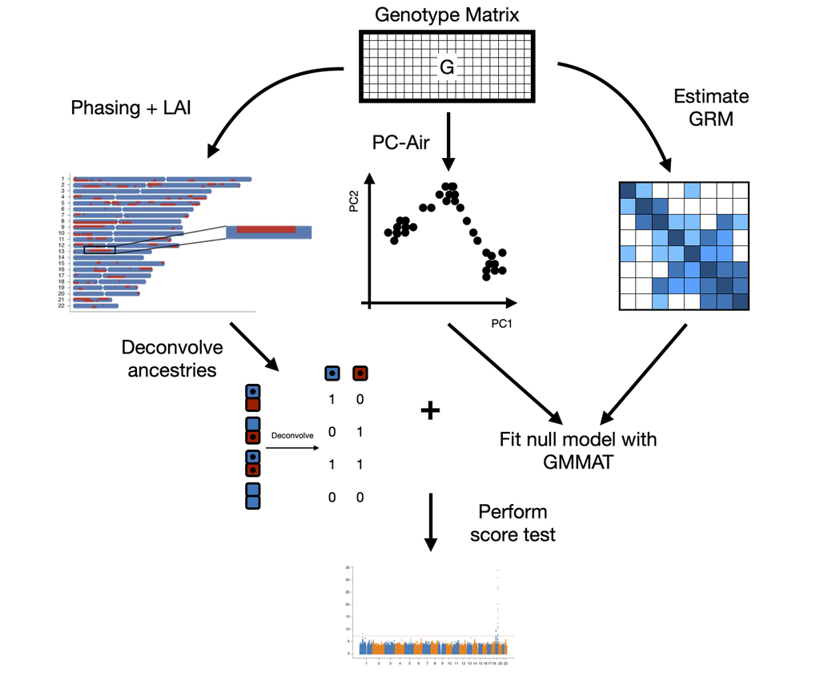

TractorMix pipeline

### Step1: Phasing and local ancestry inference

Similar to Tractor, Tractor-Mix requires good performances of phasing and local ancestry inference. We have developed a tutorial on how to use Shapeit2 and Rfmix2, please refer to [this page](https://github.com/Atkinson-Lab/Tractor-tutorial/blob/main/Rfmix.md) for more details. Briefly, one can run phasing and local ancestry inference with:

```r
# Phasing with Shapeit2
shapeit  --input-vcf Genotype.unphased.vcf.gz \
         --input-map genetic.map.txt \
         --input-ref Reference.hap.gz Reference.legend.gz Reference.sample \
         -O Genotype.phased


# Local ancestry inference with Rfmix2
rfmix -f Genotype.phased.vcf.gz \
      -r Reference.phased.vcf.gz \
      -m Reference.meta.tsv \
      -g genetic.map.txt \
      -o Genotype.deconvoluted \
      --chromosome=1
```

For the reference panel, users may want to use continental/subcontinental populations that accurately match the query admixture. (e.g. for the African-American cohort, one may want to use all continental AFR and EUR populations from 1000 Genome projects as the reference panel). Excessive ancestry calls can reduce statistical power. For instance, a cohort with `[AFR, EUR, AMR]` = `[60%, 38%, 2%]` is not preferable for Tractor-Mix since AMR only composes 2%. Instead, calling such cohort 2-way admixture is more appropriate.

### Step2: Deconvolute genetic markers by local ancestry

We will use the same infrastructure as Tractor to extract Tracts. Please refer to [this page](https://github.com/Atkinson-Lab/Tractor-tutorial/blob/main/Extract.md) for tutorial and [this page](https://github.com/Atkinson-Lab/Tractor/blob/master/ExtractTracts.py) for source code.Briefly:

```r
python Tractor/ExtractTracts.py \
      --msp Genotype.deconvoluted \
      --vcf Genotype.phased \
      --zipped \
      --num-ancs 2
```

### Step3: Estimate covariates with PC-Air

In the linear/logistic mixed model, we typically use PC or admixture proportion to capture population stratification. For a cohort with related samples, a common practice is to first partition samples into independent subsets and relative subsets. We construct the PC space with independent samples, then project relatives into the space. Through this approach, principal components will not be driven by family structure. This approach has been implemented in the R package GENESIS, which can be installed through Bioconductor. The tutorial on running PC-Air can be found [here](http://bioconductor.org/packages/release/bioc/vignettes/GENESIS/inst/doc/pcair.html). If you have vcf files in hand, you may need to convert them into GDS file formats so that they can be processed by GENESIS (`vcf ---> PLINK ---> GDS`). GENESIS then performs LD prune, partition samples, and runs PC-Air. Once finished running PC-Air, one may want to save the results as a tsv file.

```r
# Plink 1.9
plink --vcf YourFile.vcf --make-bed --out YourFile
```

```r
# convert Plink to vcf files
snpgdsBED2GDS(bed.fn = "YourFile.bed",
              bim.fn = "YourFile.bim",
              fam.fn = "YourFile.fam",
              out.gdsfn = "YourFile.gds")


# Perform LD prunning here/with Plink:
snpgdsLDpruning(...)

# read GDS
gds <- GdsGenotypeReader(filename = "YourFile.gds")

# Calculate kinship
KINGmat = snpgdsIBDKING(gds)$kinship

# PC Air calculation
gdsData <- GenotypeData(gds)
PCair <- pcair(gdsData, kinobj = KINGmat, divobj = KINGmat)
PCairpart <- pcairPartition(kinobj = KINGmat, divobj = KINGmat)
write.table(PCair.out .... )
```

**[Note: In our current theoretical simulations and [GENESIS paper](https://www.ncbi.nlm.nih.gov/pmc/articles/PMC7904076/#sup1), the difference between raw PCA vs PC-Air is minor]**

### Step4: Estimate GRM/kinship with PC-Relate

Once finish running PC-Air, once can run PC-Relate (refer to [the same tutorial](http://bioconductor.org/packages/release/bioc/vignettes/GENESIS/inst/doc/pcair.html)) to obtain the estimated kinship matrix. PC-Relate will produce a sparse matrix, and we may want to convert it into as standard matrix by `as.matrix(pcrelateToMatrix(PCrelate, ...))`. Please note that occasionally, GENESIS can scramble the order of samples in the output file, please make sure the order is correct.

```r
# PC relate calculation
gdsData <- GenotypeBlockIterator(gdsData, ...)
PCrelate <- pcrelate(gdsData, pcs = PCair$vectors[,1:2],
                          training.set = PCairpart$unrels,
                          BPPARAM = BiocParallel::SerialParam())

write.table(PCrelate.out .... )
```

**[Note: In our current theoretical simulations and [GENESIS paper](https://www.ncbi.nlm.nih.gov/pmc/articles/PMC7904076/#sup1), the difference between raw GRM vs PC-Relate is minor]**

### Step5: Fit the null model with GMMAT

GMMAT can be installed with `install.packages("GMMAT")`. We will use the following command to fit the null model:

```r
# continuous:
Model_Null =   glmmkin(fixed = Pheno ~  Covariates,
                       data = YourDf, id = "ID", kins = GRM,
                       family = gaussian(link = "identity"))

# dichotomous:
Model_Null =   glmmkin(fixed = Pheno ~  Covariates,
                       data = YourDf, id = "ID", kins = GRM,
                       family = binomial(link = "logit"))
```

In essence, we fit a linear/logistic mixed model that takes covariates as the fixed effect term, and takes GRM as the random effect term. This is the first step of Rao’s score test, where we fit the model under the null hypothesis and obtain its gradient and information matrix.

For now, please ensure that the order of ID in your covariate file matches with the GRM order; Please also ensure there is no missing value in GRM, phenotype, or covariates. I will try to implement a better version of TractorMix to handle this down the road.

### Step6: Run Tractor-Mix

```r
TractorMix.score(obj = Model_Null,
                 infiles = c("Genotype.anc0.hapcount.txt", "Genotype.anc1.hapcount.txt"),
                 outfiles = "result.tsv" )
```

From TractorMix, you should obtain:  
* a joint p-value (to reject the null hypothesis H0: beta(anc0) = beta(anc1) = 0)  
* ancestry-specific effect size estimates (Eff0, Eff1)  
* ancestry-specific p values (PVal0, PVal1)

For a dataset with 5,000 samples and 1,000,000 markers, the program can take 5 days to finish with a single computing node. But you can increase the speed by submitting an array job in the cluster.

We are still improving TractorMix in error handling, computation speed, etc.